# Comparing rsprite2 and scrutiny+tides’ implementations of granularity + range testing

Ian Hussey

22 June, 2025

# Overview

{rsprite2} and {scrutiny} both provide implementations of GRIM and GRIMMER. However, they seem to return different conclusions for many values.

I originally became interested in this when looking into rsprite2::.sd_limits() when thinking about how to implement such bounds based limits on SDs in {tides}.

The two do differ in their implementations in intentional ways, i.e., rsprite2 applies not only granularity tests but also (quietly) applies bounds tests. Whereas scrutiny only applies granularity tests.

However, the results returned by the two differ on more than just this difference. In the below, I compare rsprite2 (granularity+boundary tests) vs. scrutiny(granluarity)+tides(boundary).

First I create contrast umbrella plots made with the two methods, then I try to find the reasons for disagreements.

```r
library(tidyverse)
library(janitor)
library(rsprite2)
library(scrutiny)
#devtools::install_github("ianhussey/tides")
library(tides)
library(purrr)
library(patchwork)
library(knitr)
library(kableExtra)

dir.create("models")
dir.create("plots")

min_decimals <- function(x, digits = 2) {
  sprintf(paste0("%.", digits, "f"), x)
}
```

# Comparing umbrella plots made with different packages

## Umbrella plot using rsprite::GRIMMER_test

which actually applies not only granularity testing but also bounds testing via .sd_limits()

### Generate data

```r
# create possibly version of GRIMMER_test that fails quietly, given that it seems to have a bug
possibly_GRIMMER_test = possibly(GRIMMER_test, otherwise = FALSE)

dat_rsprite2 <-
  expand_grid(mean = seq(from = 1, to = 7, by = 0.01),
              sd = seq(from = 0, to = 3.5, by = 0.01)) |>
  mutate(n_obs   = 14,
         m_prec  = 2,
         sd_prec = 2,
         n_items = 1,
         min_val = 1,
         max_val = 7) |>
  mutate(grim    = pmap(list(mean, n_obs, m_prec, n_items),
                        GRIM_test)) |>
  mutate(grimmer = pmap(list(mean, sd, n_obs, m_prec, sd_prec, n_items, min_val, max_val),
                        possibly_GRIMMER_test)) |>
  unnest(grim) |>
  unnest(grimmer)
```

### Plot

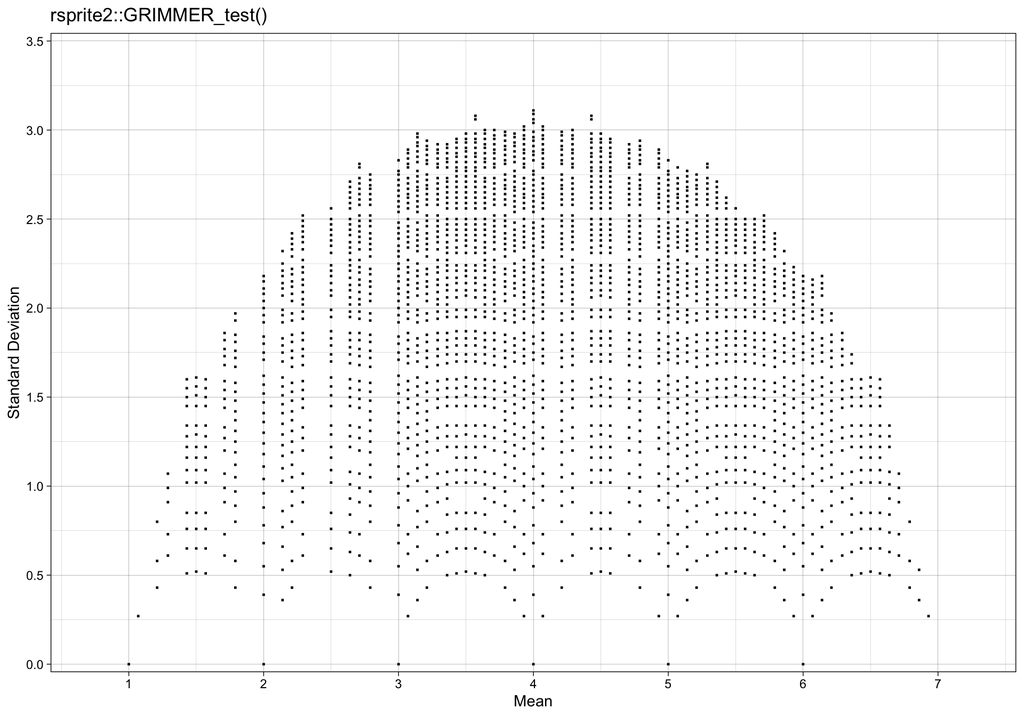

```r
# only GRIM and GRIMMER-consistent values
dat_rsprite2 |>
  filter(grim & grimmer) |>
  ggplot(aes(mean, sd)) +
  geom_point(shape = 15, size = 0.5) +
  theme_linedraw() +
  scale_y_continuous(breaks = scales::breaks_pretty(n = 8),
                     name = "Standard Deviation",
                     limit = c(0, 3.5),
                     expand = c(0.01, 0.01)) +
  scale_x_continuous(breaks = scales::breaks_pretty(n = 7),
                     name = "Mean",
                     limit = c(0.5, 7.5),
                     expand = c(0.01, 0.01)) +
  scale_color_viridis_d(begin = 0.3, end = 0.7, direction = -1) +
  ggtitle("rsprite2::GRIMMER_test()")
```

```r
ggsave("plots/umbrella plot - rsprite2::GRIMMER_test().png",
       height = 7,
       width = 10)
```

- observe the vertical gaps in the plot, and the original bug of the point at (7,0) being missing.
- some of these are due to issues with .sd_limits() eg the point at (7,0), and others seemt to be issues with rsprite2’s::GRIMMER_test implementation eg the missing column of values at 2.86.

## Umbrella plot using scrutiny::grim + scrutiny::grimmer + tides::tides

scrutiny::grim() and scrutiny::grimmer() apply granularity tests only, tides::tides() provides boundary tests on both mean and SD. Explicating boundary tests as a distinct form of consistency tests is the point of {tides}.

### Generate data

```r
# dat_scrutiny_tides <-
#   expand_grid(mean = seq(from = 0.5, to = 7.5, by = 0.01),
#               sd = seq(from = 0, to = 4, by = 0.01)) |>
#   mutate(n_obs   = 14,
#          precision = 2,
#          n_items = 1,
#          min_val = 1,
#          max_val = 7) |>
#   mutate(grim = pmap(list(as.character(mean), n_obs),
#                      grim)) |>
#   mutate(grimmer = pmap(list(as.character(mean), as.character(sd), n_obs),
#                         grimmer)) |>
#   mutate(tides = purrr::pmap(.l = list(mean = mean,
#                                        sd = sd,
#                                        n = n_obs,
#                                        min = min_val,
#                                        max = max_val,
#                                        n_items = n_items,
#                                        digits = precision),
#                              verbose = FALSE,
#                              .f = tides)) |>
#   # unnest columns
#   unnest(grim) |>
#   unnest(grimmer) |>
#   unnest(tides)
#
# write_rds(dat_scrutiny_tides, "models/dat_scrutiny_tides_n_14.rds")

dat_scrutiny_tides <- read_rds("models/dat_scrutiny_tides_n_14.rds")
```

### Plot

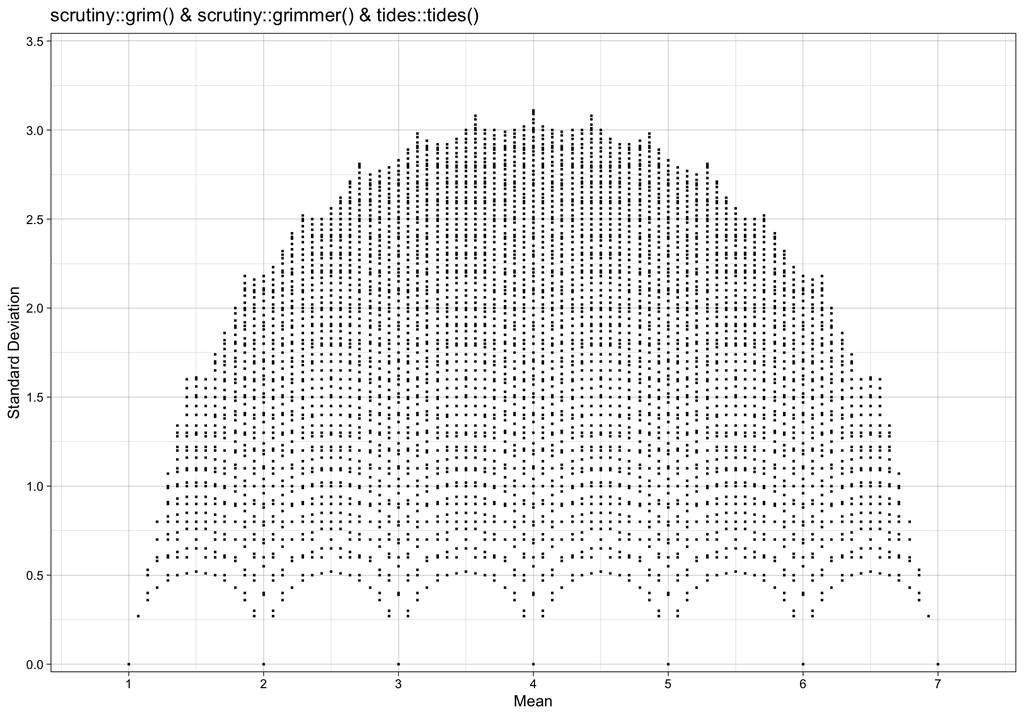

```r
dat_scrutiny_tides |>
  filter(grim & grimmer & tides_consistent) |>
  ggplot(aes(mean, sd)) +
  geom_point(shape = 15, size = 0.5) +
  theme_linedraw() +
  scale_y_continuous(breaks = scales::breaks_pretty(n = 8),
                     name = "Standard Deviation",
                     limit = c(0, 3.5),
                     expand = c(0.01, 0.01)) +
  scale_x_continuous(breaks = scales::breaks_pretty(n = 7),
                     name = "Mean",
                     limit = c(0.5, 7.5),
                     expand = c(0.01, 0.01)) +
  scale_color_viridis_d(begin = 0.3, end = 0.7, direction = -1) +
  ggtitle("scrutiny::grim() & scrutiny::grimmer() & tides::tides()")
```

```r
ggsave("plots/umbrella plot - scrutiny::grim() & scrutiny::grimmer() & tides::tides().png",
       height = 7,
       width = 10)
```

## Direct comparison of umbrella plot data points

### Explore counts

```r
dat_rsprite2_passed <- dat_rsprite2 |>
  filter(grim & grimmer) |>
  select(mean, sd, n_obs)

nrow(dat_rsprite2_passed)
```

```
## [1] 2305
```

```r
dat_rsprite2_passed |>
  distinct(mean) |>
  count()
```

```
## # A tibble: 1 × 1
##       n
##   <int>
## 1    69
```

```r
dat_scrutiny_tides_passed <- dat_scrutiny_tides |>
  filter(grim & grimmer & tides_consistent) |>
  select(mean, sd, n_obs)

nrow(dat_scrutiny_tides)
```

```
## [1] 281101
```

```r
dat_scrutiny_tides |>
  distinct(mean) |>
  count()
```

```
## # A tibble: 1 × 1
##       n
##   <int>
## 1   701
```

```r
dat_scrutiny_tides_not_rsprite2 <- dat_scrutiny_tides_passed |>
  anti_join(dat_scrutiny_tides_passed, by = join_by(mean, sd, n_obs))

nrow(dat_scrutiny_tides_not_rsprite2)
```

```
## [1] 0
```

```r
dat_scrutiny_tides_not_rsprite2 |>
  distinct(mean) |>
  count()
```

```
## # A tibble: 1 × 1
##       n
##   <int>
## 1     0
```

### Plot

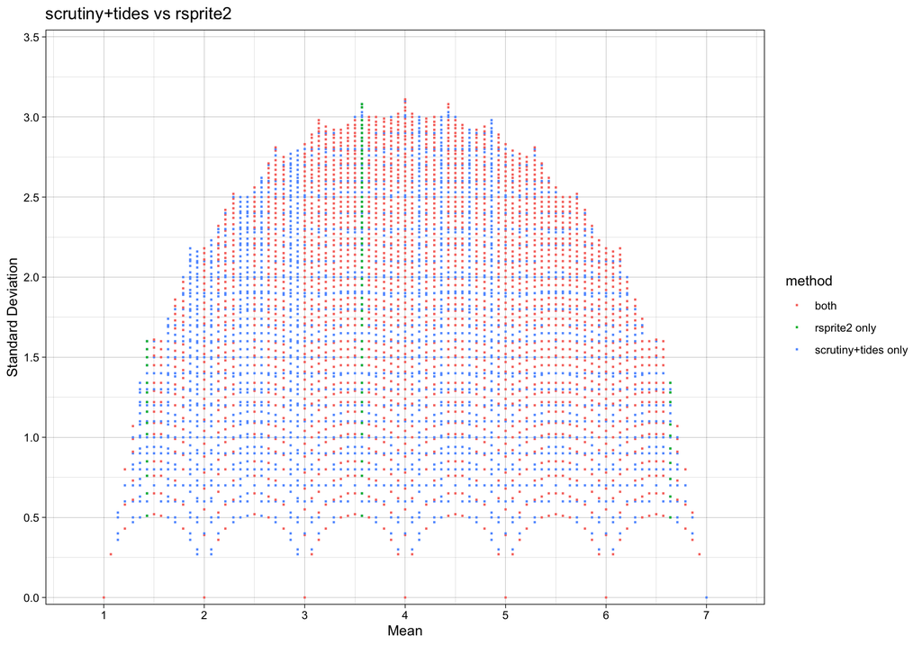

```r
dat_combined <- dat_scrutiny_tides_passed |>
  mutate(scrutiny_tides = TRUE) |>
  full_join(dat_rsprite2_passed |> mutate(rsprite2 = TRUE),
            by = join_by(mean, sd, n_obs)) |>
  mutate(method = case_when(scrutiny_tides + rsprite2 == 2 ~ "both",
                            scrutiny_tides + rsprite2 == 0 ~ "neither",
                            scrutiny_tides & is.na(rsprite2) ~ "scrutiny+tides only",
                            is.na(scrutiny_tides) & rsprite2 ~ "rsprite2 only"))

dat_combined |>
  ggplot(aes(mean, sd, color = method)) +
  geom_point(shape = 15, size = 0.5) +
  theme_linedraw() +
  scale_y_continuous(breaks = scales::breaks_pretty(n = 8),
                     name = "Standard Deviation",
                     limit = c(0, 3.5),
                     expand = c(0.01, 0.01)) +
  scale_x_continuous(breaks = scales::breaks_pretty(n = 7),
                     name = "Mean",
                     limit = c(0.5, 7.5),
                     expand = c(0.01, 0.01)) +
  #scale_color_viridis_d(begin = 0.1, end = 0.9, direction = -1) +
  ggtitle("scrutiny+tides vs rsprite2")
```

```r
ggsave("plots/umbrella plot - scrutiny+tides vs. rpsrite2.png",
       height = 7,
       width = 10)

dat_combined |>
  count(method)
```

```
## # A tibble: 3 × 2
##   method                  n
##   <chr>               <int>
## 1 both                 2229
## 2 rsprite2 only          76
## 3 scrutiny+tides only  2261
```

### Unique to one method

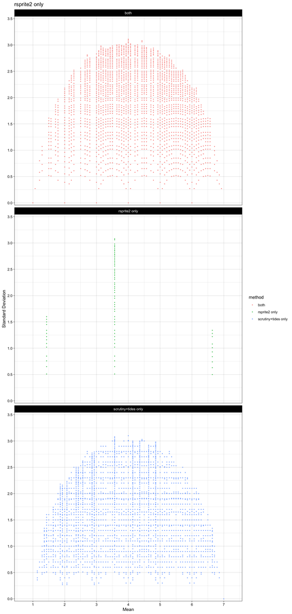

```r
dat_combined |>
  ggplot(aes(mean, sd, color = method)) +
  geom_point(shape = 15, size = 0.5) +
  theme_linedraw() +
  scale_y_continuous(breaks = scales::breaks_pretty(n = 8),
                     name = "Standard Deviation",
                     limit = c(0, 3.5),
                     expand = c(0.01, 0.01)) +
  scale_x_continuous(breaks = scales::breaks_pretty(n = 7),
                     name = "Mean",
                     limit = c(0.5, 7.5),
                     expand = c(0.01, 0.01)) +
  #scale_color_viridis_d(begin = 0.1, end = 0.9, direction = -1) +
  ggtitle("rsprite2 only") +
  facet_wrap(~method, ncol = 1)
```

```r
ggsave("plots/umbrella plot - facet by method.png",
       height = 21,
       width = 10)
```

# What gives rise to the differences between the methods?

## Implementation of SD bounds in rsprite2::.sd_limits()

Demonstrate the problem:

This works correctly: all participants respond 1, therefore M = 1, SD = 0

```r
n_digits <- 2

dat <-
  tibble(score = rep(1, times = 100)) |>
  summarize(mean = round_half_up(mean(score), n_digits),
            sd = round_half_up(sd(score), n_digits),
            n = n())

GRIMMER_test(mean = dat$mean,
             sd = dat$sd,
             n_obs = dat$n,
             m_prec = n_digits,
             sd_prec = n_digits,
             n_items = 1,
             min_val = 1,
             max_val = 7)
```

```
## [1] TRUE
```

bug: this should also pass as only the mean changes from 1.0 to 7.0, but it fails.

Chunk set to do not run so to allow knit.

```r
dat <-
  tibble(score = rep(7, times = 100)) |>
  summarize(mean = round_half_up(mean(score), n_digits),
            sd = round_half_up(sd(score), n_digits),
            n = n())

GRIMMER_test(mean = dat$mean,
             sd = dat$sd,
             n_obs = dat$n,
             m_prec = n_digits,
             sd_prec = n_digits,
             n_items = 1,
             min_val = 1,
             max_val = 7)
```

### original code for .sd_limits

```r
.sd_limits <- function(n_obs, mean, min_val, max_val, sd_prec = NULL, n_items = 1) {

  if (is.null(sd_prec)) {
    sd_prec <- max(nchar(sub("^[0-9]*", "", mean)) - 1, 0)
  }

  result <- c(-Inf, Inf)

  aMax <- min_val                                # "aMax" means "value of a to produce the max SD"
  aMin <- floor(mean*n_items)/n_items
  bMax <- max(max_val, min_val + 1, aMin + 1)   # sanity check (just max_val would normally be ok)
  bMin <- aMin + 1/n_items
  total <- round(mean * n_obs * n_items)/n_items

  poss_values <- max_val
  for (i in seq_len(n_items)) {
    poss_values <- c(poss_values, min_val:(max_val-1) + (1 / n_items) * (i - 1))
  }
  poss_values <- sort(poss_values)

  for (abm in list(c(aMin, bMin, 1), c(aMax, bMax, 2))) {

    a <- abm[1]
    b <- abm[2]
    m <- abm[3]


    k <- round((total - (n_obs * b)) / (a - b))
    k <- min(max(k, 1), n_obs - 1)               # ensure there is at least one of each of two numbers
    vec <- c(rep(a, k), rep(b, n_obs - k))
    diff <- sum(vec) - total

    if ((diff < 0)) {
      vec <- c(rep(a, k - 1), a + abs(diff), rep(b, n_obs - k))
    }
    else if ((diff > 0)) {
      vec <- c(rep(a, k), b - diff, rep(b, n_obs - k - 1))
    }

    # # Debugging: Print relevant information to diagnose the issue
    # cat("Iteration for a =", a, "b =", b, "\n")
    # cat("Generated vec:", vec, "\n")
    # cat("Mean of vec:", mean(vec), "Expected mean:", mean, "\n")
    # cat("SD of vec:", sd(vec), "\n\n")

    if (round(mean(vec), sd_prec) != round(mean, sd_prec) | !all(floor(vec*10e9) %in% floor(poss_values*10e9))) {
      stop("Error in calculating range of possible standard deviations")
    }

    result[m] <- round(sd(vec), sd_prec)
  }

  return(result)
}
```

### potentially fixed code

```r
.sd_limits_fixed <- function(n_obs, mean, min_val, max_val, sd_prec = NULL, n_items = 1) {

  if (is.null(sd_prec)) {
    sd_prec <- max(nchar(sub("^[0-9]*", "", mean)) - 1, 0)
  }

  result <- c(-Inf, Inf)

  aMax <- min_val
  aMin <- floor(mean*n_items)/n_items
  # bMax <- max(max_val, min_val + 1, aMin + 1) # original
  bMax <- min(max(max_val, min_val + 1, aMin + 1), max_val)   # Adjusted here
  # bMin <- aMin + 1/n_items # original
  bMin <- min(aMin + 1/n_items, max_val)                      # Adjusted here
  total <- round(mean * n_obs * n_items)/n_items

  poss_values <- max_val
  for (i in seq_len(n_items)) {
    poss_values <- c(poss_values, min_val:(max_val-1) + (1 / n_items) * (i - 1))
  }
  poss_values <- sort(poss_values)

  for (abm in list(c(aMin, bMin, 1), c(aMax, bMax, 2))) {

    a <- abm[1]
    b <- abm[2]
    m <- abm[3]

    # Adjust a and b to be within min_val and max_val
    a <- min(max(a, min_val), max_val)
    b <- min(max(b, min_val), max_val)

    if (a == b) {
      vec <- rep(a, n_obs)
    } else {
      k <- round((total - (n_obs * b)) / (a - b))
      k <- min(max(k, 1), n_obs - 1)
      vec <- c(rep(a, k), rep(b, n_obs - k))
      diff <- sum(vec) - total

      if ((diff < 0)) {
        vec <- c(rep(a, k - 1), a + abs(diff), rep(b, n_obs - k))
      } else if ((diff > 0)) {
        vec <- c(rep(a, k), b - diff, rep(b, n_obs - k - 1))
      }
    }

    if (round(mean(vec), sd_prec) != round(mean, sd_prec) | !all(floor(vec*10e9) %in% floor(poss_values*10e9))) {
      stop("Error in calculating range of possible standard deviations")
    }

    result[m] <- round(sd(vec), sd_prec)
  }

  return(result)
}
```

now works: mean of 7.0 now passes

```r
n_digits <- 2

# now works correctly
# all participants respond 7, therefore M = 7, SD = 0
dat <-
  tibble(score = rep(7, times = 100)) |>
  summarize(mean = round_half_up(mean(score), n_digits),
            sd = round_half_up(sd(score), n_digits),
            n = n())

.sd_limits_fixed(n_obs = dat$n,
                 mean = dat$mean,
                 min_val = 1,
                 max_val = 7,
                 sd_prec = n_digits,
                 n_items = 1)
```

```
## [1] 0 0
```

- I employ the above corrected code in tides::tides(), which are used in the umbrella plots at the top of the file.

## Sample vs pooled SD?

The differences are mostly related to SDs/GRIMMER, but a few specific values of mean/GRIM too.

Possibly use of sample vs population SD? the prepubmed checker checks both, and passes one vs the other following a similar pattern to that in the data here:

http://www.prepubmed.org/grimmer_sd/?type=unknown&direction=Up&sd=0.90&mean=6.57&size=14